# Trabalho de Simulação final

Gabriel Mizuno

11/09/2018

# 1-)

## a-)

Algoritmo 1:

```r
poisson=function(lambda){
  u <- runif(1)
  i <- 0; p <- exp(-1*lambda); f <-p
  while(u>=f){
      i <- i+1; p <- p*lambda/i; f <- f+p
    }
    x <- i
  cat("Número gerado é;",x)
}
poisson(10)
```

```
## Número gerado é; 12
```

Algoritmo 2:  
Esse algoritmo é mais eficiente para um $\lambda$ grande

```r
poisson <- function(lambda){
  u <- runif(1); I <- round(lambda); f <- ppois(I,lambda)
  if (u<f){
    i <- I; p <- dpois(i,lambda); f <- f-p
    while (u<f){
      i <- i-1; p <- dpois(i,lambda); f <- f-p
    }
    x <- i
    return(x)
  }
  else{
    i <- I+1; p <- dpois(i,lambda); f <- f+p
    while (u>=f){
      i <- i+1; p <- p*lambda/i; f <- f+p
    }
    x <- i+1
    cat("Número gerado é;",x)
  }
}
poisson(1000)
```

```
## [1] 993
```

## b-):

Nessa questão estamos contando o número de passos necessário para gerar um número com os algoritmos usados no item a.

Contando 1:

```r
poisson_c1=function(lambda){
  u <- runif(1)
  i <- 0;p <- exp(-1*lambda);f <-p;cont <- 1
  while(u>=f){
    i <- i+1;p <- p*lambda/i;f <- f+p
    cont<- cont+1
  }
  passos <- cont
  return(passos)
}
```

Contando 2:

```r
poisson_c2 <- function(lambda){
  u <- runif(1); I <- as.integer(lambda); f <- ppois(I,lambda); passos <- 1
  if (u<f){
    i <- I; p <- dpois(i,lambda); f <- f-p
    while (u<f){
      i <- i-1; p <- dpois(i,lambda); f <- f-p
      passos <- passos+1
    }
    return(passos)
  }
  else{
    i <- I+1; p <- dpois(i,lambda); f <- f+p
    while (u>=f){
      i <- i+1; p <- p*lambda/i; f <- f+p
      passos <- passos+1
    }
    return(passos)
  }
}
```

Analisando quantidade de passos necessário para gerar um número usando o Contando 1

```r
y <- 0
for (i in 1:1000){
  y[i] <- poisson_c1(400)
}
mean(y)
```

```
## [1] 400.706
```

Analisando quantidade de passos necessário para gerar um número usando o Contando 2

```r
x <- 0
for (i in 1:1000){
  x[i] <- poisson_c2(400)
}
mean(x)
```

```
## [1] 16.079
```

Notamos que o número de ciclos usando poisson_c2 é bem menor do que o número de ciclos para gerar usando poisson_c1, além disso temos uma restrição quanto ao valor de lambda sendo que no primeiro método (poisson_c1) não poderia ser muito grande sem um alto custo computacional( basta testar alguns casos para verificar um aumento na lentidão), já usando o segundo método essa restrição é menor.

Montando o gráfico do número de interações por $\lambda$. Estou gerando vários números com uma distribuição de Poisson e vendo a media das interações de cada um dos algoritmos.

```r
a <- 0
for (i in 1:20){
  c <- 0
  for (j in 1:100000){
    c[j] <- poisson_c1(i)
  }
  a[i] <- mean(c)
}
b <- 0
for (i in 1:20){
  c <- 0
  for (j in 1:10000){
    c[j] <- poisson_c2(i)
  }
  b[i] <- mean(c)
}
```

Onde a linha azul representa no número de ciclos no algoritmo 1 e a vermelha do algoritmo 2.

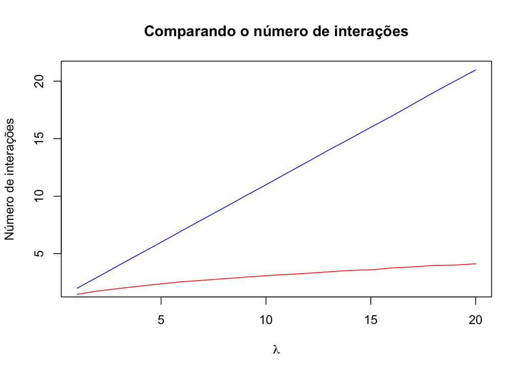

```r
plot(1:20,a,type='l',xlab=expression(lambda),ylab="Número de interações",col="blue",main="Comparando o número de interações")
lines(1:20,b,type="l",col='red')
```

# 2-)

## a-)

Estou usando o método da rejeição e para isso estou usando uma uniforme discreta $Y\sim \lbrace 1,\cdots,10 \rbrace$ Criando a função para gerar um numero aletório de uma função discreta do enunciado.

```r
gerando_X <- function(p,q){
  #Achando a constante c
  c <- max(p/q)

  #Estou gerando Y
  u1 <- runif(1)
  Y <- as.integer(10*u1)+1
  u2 <- runif(1);u2

  #Gerando X
  while(u2>=p[Y]/(c*q[Y])){
    u1 <- runif(1)
    Y <- as.integer(10*u1)+1
    u2 <- runif(1)
  }
  X <- Y
  return(X)
}
```

## b-)

Vamos gerar um exponencial 1

```r
expo <- function(lambda){
  u <- runif(1)
  y <- -log(1-u)/lambda
  return(y)
}
```

Vamos gerar primeiro normal padrão e depois com uma transformação teremos uma normal qualquer Vamos usar o método da rejeição com $c=\frac{2e^{1/2}}{\sqrt(2\pi)}$ e $h(y)=e^{\frac{-(y-1)^2}{2}}$

```r
normal <- function(mu,sigma2){
  y <- expo(1); y
  u1 <- runif(1)
  while (u1>=exp(-(y-1)**2/2)){
    y <- expo(1)
    u1 <- runif(1)
  }
  u2 <- runif(1)
  if (u2<=.5){
    x <- (-1)*y
  }
  else {
    x <- y
  }
  #Gerando uma normal sem ser padrão
  x <- sigma2*x + mu
  return(x)
}

#Testando se esta correto

a <- 0
for (i in 1:1000){
  a[i] <- normal(2,1)
}
mean(a)
```

```
## [1] 2.010334
```